# Analyse descriptive de graphe

Vanesse Labeyrie & Sarah Ouadah

Mercredi après-midi 12 Juin 2019

Durée du TP : 3h

# Introduction

## Plan

1. Parcourir un graphe : quelques définitions
2. Caractéristiques des noeuds : mesures de centralité
- degré
- closeness
- betweeness
3. Caractéristiques locales et globales du réseau : motifs, “densité” et partitionnement
- motifs : définitions, réciprocité et transitivité
- cliques et densité
- partitionnement : modularité

## Les packages

```r
library(igraph)
library(igraphdata)
library(sand)
```

## Définition d’un graphe aléatoire

Un graphe aléatoire $\mathcal{G} =(\mathcal{V}=\{1, \dots n\}, \mathcal{E})$ est la représentation mathématique d’un réseau d’interaction.

Variable d’intérêt - Données : $\mathbf{Y}$ la matrice d’adjacence de $\mathcal{G}$
$$Y_{ij}=\left\{\begin{array}{lcl}
1\mbox{ ou autre valeur}& &\mbox{si $(i, j) \in \mathcal{E}$ (arête)}\\
0& &\mbox{sinon}\end{array}\right.$$

et $Y_{ii} = 0,\forall i$. Lorsque le graphe est non dirigé $Y_{ij} = Y_{ji},\forall i\neq j$.

Remarque : Les $Y_{ij}$ sont des variables aléatoires. Leur réalisations, i.e. les valeurs que l’on observe, se réalisent donc avec une certaine probabilité et proviennent d’un échantillon de la population.

- Le nombre de noeuds $n=|\mathcal{V}|$ est appelé l’ordre du graphe.
- Le nombre d’arêtes $|\mathcal{E}|$ est appelé la taille du graphe.

# 1) Parcourir un graphe : quelques définitions

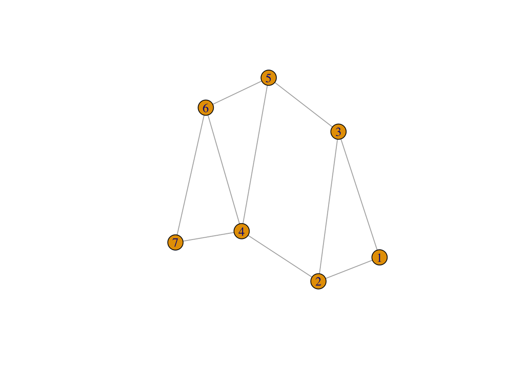

Matrice d’adjacence $\mathbf{Y}$ :

```r
get.adjacency(g)
```

```
## 7 x 7 sparse Matrix of class "dgCMatrix"
##   1 2 3 4 5 6 7
## 1 . 1 1 . . . .
## 2 1 . 1 1 . . .
## 3 1 1 . . 1 . .
## 4 . 1 . . 1 1 1
## 5 . . 1 1 . 1 .
## 6 . . . 1 1 . 1
## 7 . . . 1 . 1 .
```

- Voisins :

Les voisins d’un noeud sont les noeuds avec lesquels il est connecté.
$$\mathcal{N}(i) = \{j\in\mathcal{V} : (i,j) \in \mathcal{E}\}$$

```r
neighbors(g,5)
```

```
## + 3/7 vertices, named, from 5f99b43:
## [1] 3 4 6
```

- Chemin (path) :

Dans un graphe non dirigé, un chemin entre $i\in \mathcal{V}$ et $j\in \mathcal{V}$ est une suite d’arêtes $e_1,\dots,e_k$ telles que $\forall 1 \leq \ell < k$, toutes les arêtes consécutives $(e_\ell, e_{\ell+1})$ partagent un noeud dans $\mathcal{V}$, $e_1$ commence en $i$ et $e_k$ finit en $j$, et ceci sans arêtes et sans noeuds répétés.

- Cycle :

On parle de cycle lorsqu’un chemin, avec au moins trois noeuds, débute avec une arête $e_1$ qui part de $i$ et termine avec une arête $e_k$ qui finit en $i$.

- Acyclique :

Un graphe est dit acyclique lorsqu’il ne contient aucun cycle.

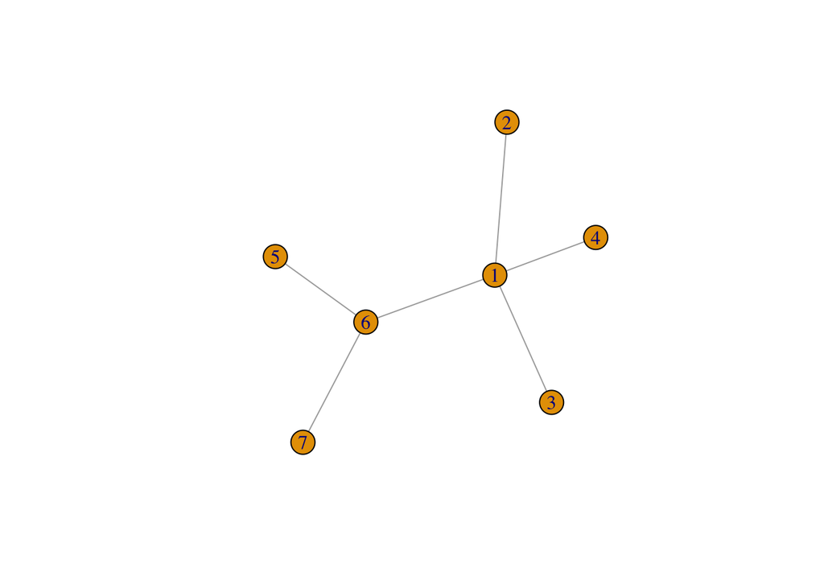

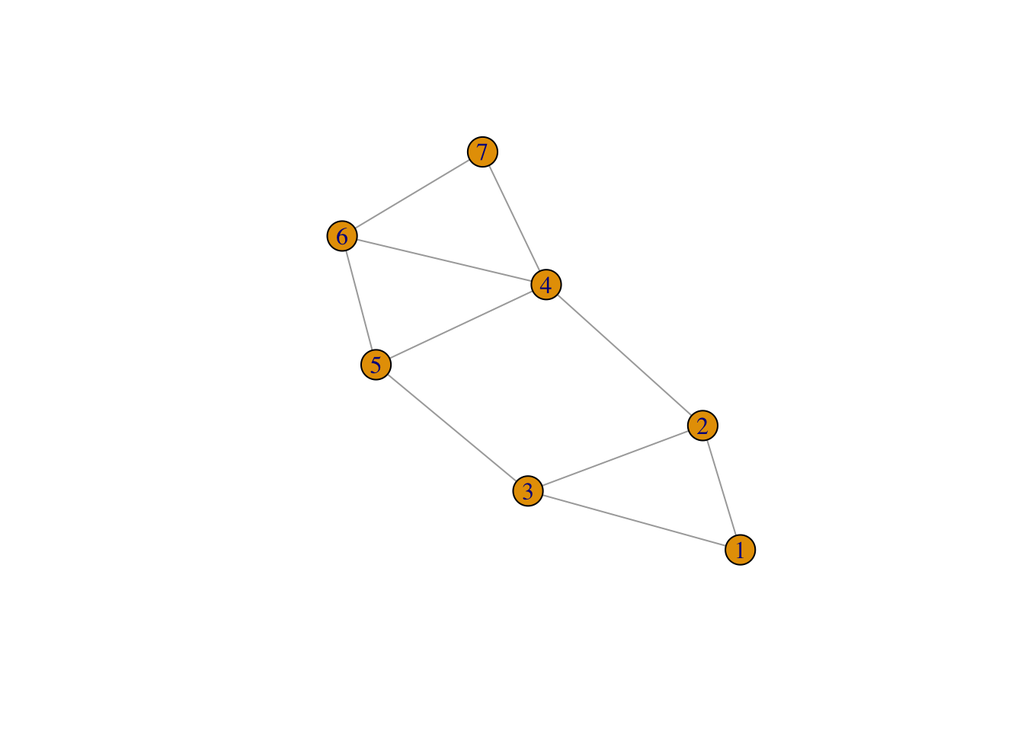

- Distance :

La distance entre $i\in \mathcal{V}$ et $j\in \mathcal{V}$ est la longueur $\ell_{ij}$ du plus court chemin entre ces noeuds. La distance moyenne est définie par
$$\bar{d}(\mathcal{G})= \frac{1}{n(n-1)}\sum_{(i,j)\in \mathcal{V}^2} \ell_{ij}.$$

```r
shortest_paths(g, 3,7)$vpath
```

```
## [[1]]
## + 4/7 vertices, named, from 5f99b43:
## [1] 3 2 4 7
```

```r
mean_distance(g)
```

```
## [1] 1.666667
```

```r
average.path.length(g)
```

```
## [1] 1.666667
```

On retrouvera cette notion de distance, à partir de laquelle sont construites des mesures de centralité d’un noeud.

- Diamètre :

Le diamètre est la plus longue distance possible entre deux noeuds :
$$\mathrm{diametre(\mathcal{G})} = \max_{(i,j)\in\mathcal{V}^2} \left(\ell_{ij}\right)$$

```r
diameter(g)
```

```
## [1] 3
```

- Connexe :

Un graphe est dit connexe lorsqu’il existe un chemin entre toute paire de noeud.

```r
is.connected(g)
```

```
## [1] TRUE
```

- Composante connexe :

Une composante connexe est un sous-ensemble de $\mathcal{V}_s\subset\mathcal{V}$ tel qu’il existe un chemin entre tout $i,j\in\mathcal{V}_s$.

```r
comps <- decompose.graph(g)
table(sapply(comps, vcount))
```

```
##
## 7
## 1
```

Le graphe étudié est constitué d’une seule composante constituée de 7 noeuds.

On retrouvera cette notion de connexité/connectivité qui est liée à celle de densité d’un graphe ou d’une de ses composantes.

# 2) Caractéristiques des noeuds : mesures de centralité

La centralité d’un noeud permet de traduire l’importance d’un noeud dans un réseau. On s’intéresse à ces trois mesures de centralité : le degré, la closeness et la betweenness.

Il existe diverses mesures de centralité mais comme l’a observé Freeman en 1979 (c’est toujours d’actualité !) : “There is certainly no unanimity on exactly what centrality is or on its conceptual foundations, and there is a little agreement on the proper procedure for its measurement”. Notons toutefois que le degré d’un noeud est incontestablement la mesure de centralité la plus utilisée.

## 2.1) Degré d’un noeud

- Rappel sur le réseau du club de karaté :

Ce réseau a été observé pendant deux ans dans les années 70. Un noeud est un membre du club et une arête correspond à une interaction sociale entre deux membres. Suite à une dispute entre un enseignant et un membre de l’administration identifiés, il y a eu “séparation” en deux groupes. On a l’appartenance des membres aux deux camps ainsi que la fréquence relative d’interaction entre eux.

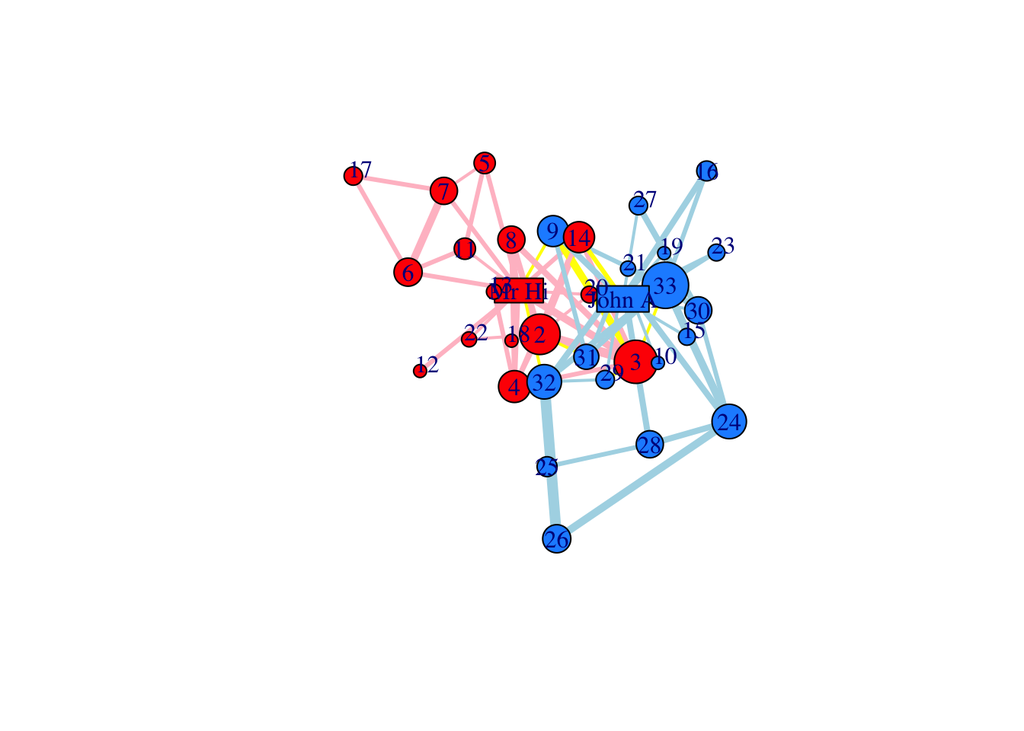

- Degré

Le degré d’un noeud $i\in\mathcal{V}$ est le nombre d’arêtes qui le relie aux autres :
$$D_i=\sum_i Y_{ij}.$$

La distribution des degrés pour le réseau du club de karaté :

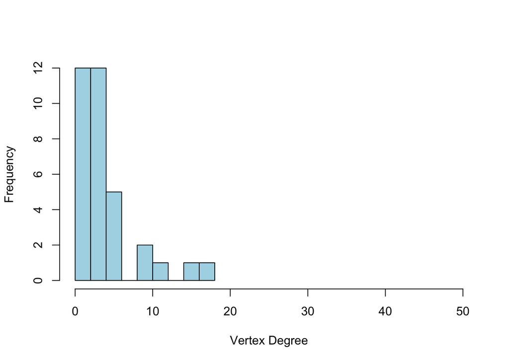

```r
hist(degree(karate), col="lightblue", xlim=c(0,50), xlab="Vertex Degree", ylab="Frequency", main="")
```

- Degré d’un graphe dirigé

Notons que le réseau du club de karaté est un graphe non dirigé, donc pour un noeud on compte simplement son nombre de voisins. Dans le cas d’un graphe dirigé, on pourrait calculer le degré entrant ou sortant :

degree(data_dirige,mode=“in”) et degree(data_dirige,mode=“out”)

- Degré d’un graphe valué

Pour les réseaux valués, une généralisation du degré est la notion de force du noeud qui consiste en la somme des poids des arêtes incidentes au noeud. Pour le réseau du club, les poids correspondent aux fréquences d’interaction entre ses membres.

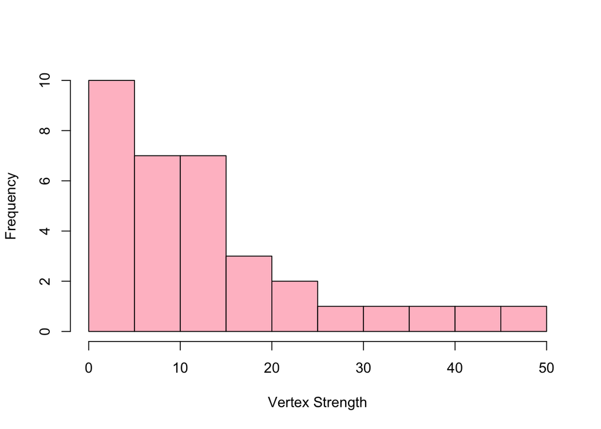

```r
hist(graph.strength(karate), col="pink", xlab="Vertex Strength", ylab="Frequency", main="")
```

On ne distingue plus les trois groupes de noeuds selon leur degrés mais plutôt deux, l’un avec un degré faible et moyen et l’autre plus fort.

On considère maintenant un réseau d’intéraction entre 2617 protéines.

```r
data(yeast)
vcount(yeast)
```

```
## [1] 2617
```

```r
ecount(yeast)
```

```
## [1] 11855
```

La distribution des degrés pour le réseau de protéines :

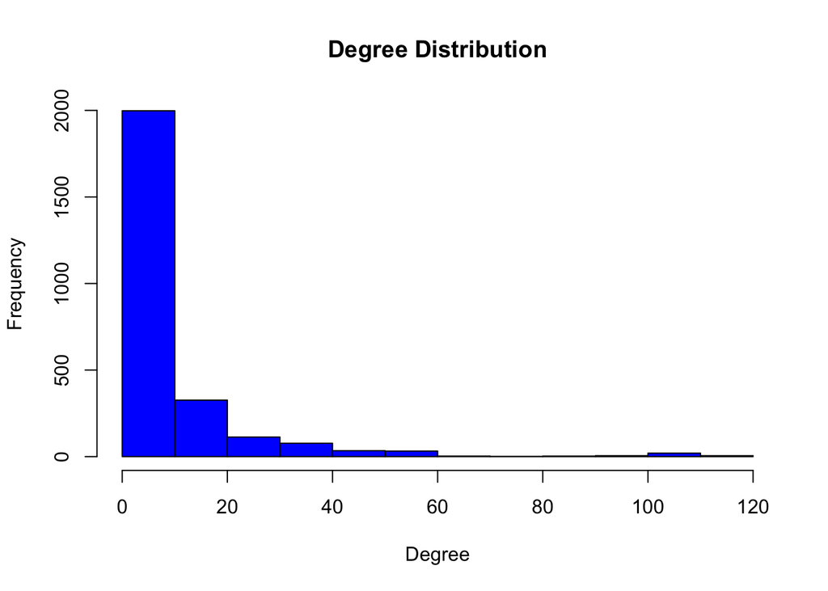

```r
d.yeast <- degree(yeast)
hist(d.yeast,col="blue", xlab="Degree", ylab="Frequency", main="Degree Distribution")
```

On voit que la majorité des protéines ont un degré faible et qu’il y a une petite fraction de protéines à très fort degré. La distribution des degrés suit ici une loi dite de puissance. C’est un phénomène rencontré dans nombre de domaines scientifiques.

Etant donné la décroissance exponentielle de la distribution des degrés, regardons une représentation à l’échelle log-log qui permet de bien représenter linéairement cette fonction puissance :

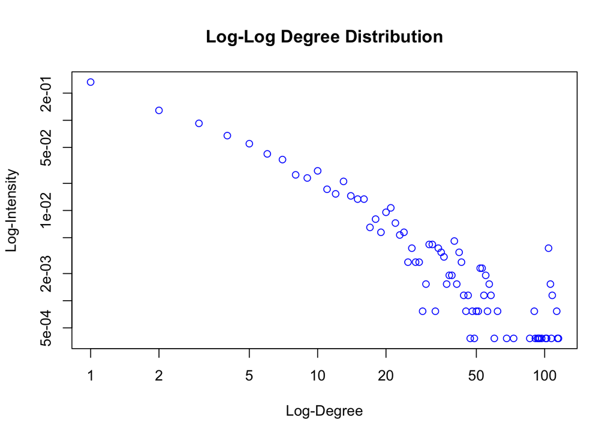

```r
dd.yeast <- degree.distribution(yeast)
d <- 1:max(d.yeast)-1
ind <- (dd.yeast != 0)
plot(d[ind], dd.yeast[ind], log="xy", col="blue", xlab=c("Log-Degree"), ylab=c("Log-Intensity"), main="Log-Log Degree Distribution")
```

Au-delà de la distribution des degrés en elle-même, il est intéressant de voir comment les noeuds de degrés particuliers interagissent entre eux. On peut alors regarder le degré moyen des voisins de chacun des noeuds d’un degré donné :

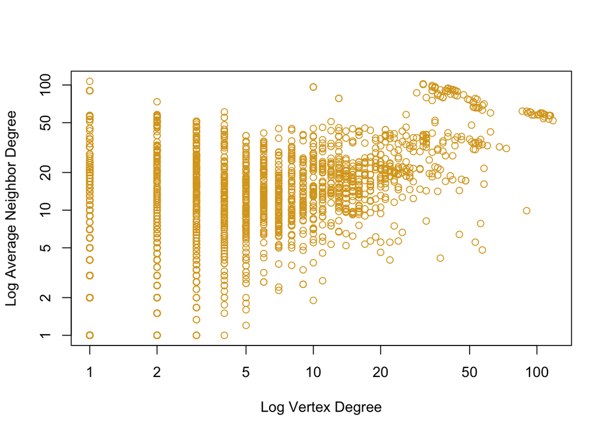

```r
a.nn.deg.yeast <- graph.knn(yeast,V(yeast))$knn
plot(d.yeast, a.nn.deg.yeast, log="xy", col="goldenrod", xlab=c("Log Vertex Degree"), ylab=c("Log Average Neighbor Degree"))
```

On voit ici que les noeuds de forts degrés sont liés à ceux ayant la même caractéristique, alors que ceux de degré faible sont liés à toutes sortes de noeuds.

## 2.2) Closeness

La mesure de closeness définit un noeud comme étant central lorsqu’il est “proche” des autres noeuds. Ceci est capturé pour un noeud $v\in\mathcal{V}$ par l’inverse de sa distance total aux autres noeuds :
$$\mathrm{CL}(v)=\frac{1}{\sum_{u\in\mathcal{V}}\mbox{dist}(v,u)}$$

Pour avoir des valeurs entre 0 et 1 il faut multiplier CL par $n-1$. Par exemple pour un motif étoilé

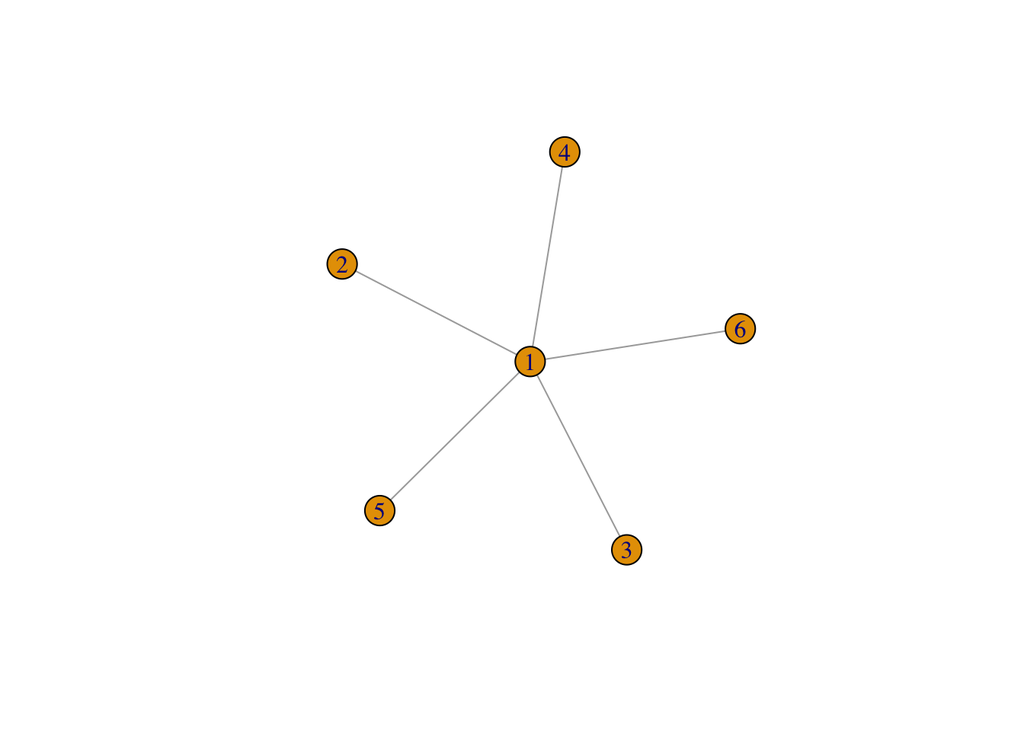

```r
closeness(star)
```

```
##         1         2         3         4         5         6
## 0.2000000 0.1111111 0.1111111 0.1111111 0.1111111 0.1111111
```

```r
closeness(star)*(vcount(star)-1)
```

```
##         1         2         3         4         5         6
## 1.0000000 0.5555556 0.5555556 0.5555556 0.5555556 0.5555556
```

Pour le réseau karaté, on a l’histogramme suivant de la closeness qui dit que les membres ont une closeness entre 0.10 et 0.25, ce qui voudrait dire qu’en moyenne tous les membres sont connectés via 5 autres membres intermédiaires (chemin de longueur 6) :

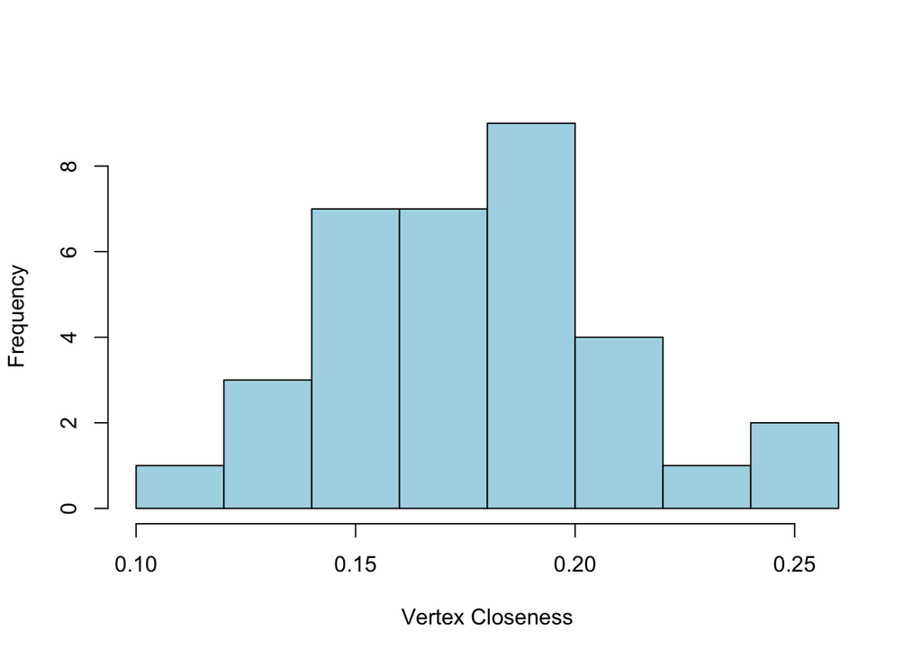

```r
n=vcount(karate)
hist(closeness(karate)*(n-1), col="lightblue", xlab="Vertex Closeness", ylab="Frequency", main="")
```

Remarque : on appelle farness d’un noeud sa distance total aux autres noeuds, c’est-à-dire la somme des longueurs des plus courts chemins entre ce dernier et tous les autres. La closeness est donc son inverse.

## 2.3) Betweenness

La mesure de betweenness définit un noeud comme étant central lorsqu’il est “proche” de nombreuses autres paires de noeuds connectées. L’importance d’un noeud est alors liée au fait qu’il se trouve sur des chemins du graphe. Elle est définie par
$$\mathrm{B}(v)=\sum_{s\neq t\neq v\in\mathcal{V}}\frac{\sigma(s,t|v)}{\sigma(s,t)}$$
où $\sigma(s,t|v)$ est le nombre total de chemins les plus courts qui passent par $v$ entre $s$ et $t$ et $\sigma(s,t)$ le nombre total de chemins les plus courts entre $s$ et $t$.

Pour avoir des valeurs entre 0 et 1 il faut diviser B par $(n-1)(n-2)/2$. On voit que la betweenness de la majorité des individus est relativement faible, les relations entre membres se font plus au sein de “petits” groupes :

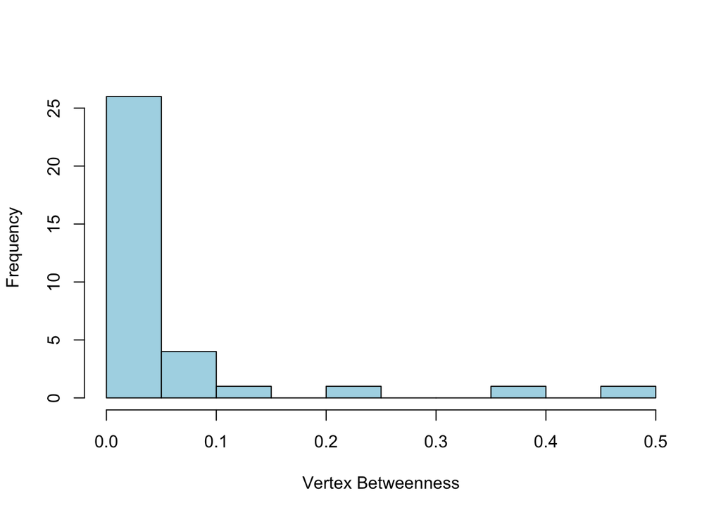

```r
 hist(betweenness(karate)/((n-1)*(n-2)/2), col="lightblue", xlab="Vertex Betweenness", ylab="Frequency", main="")
```

## 2.4) En résumé

- Une vue des trois mesures avec un layout radial, i.e avec les noeuds les plus centraux proche du centre du cercle :

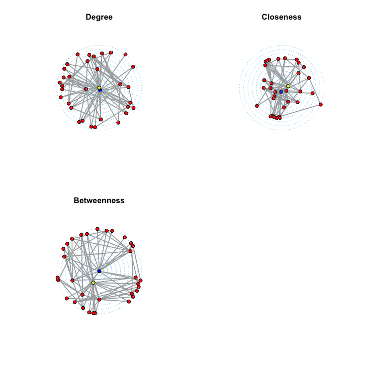

Ces figures montrent que les trois mesures présentées capturent différentes notions de centralité. L’administrateur et l’enseignant, figures centrales du club de karaté, sont représentés en jaune et bleu. On voit qu’ils se se confondent presque pour le degré alors que leur statut est clairement différent pour la betweenness. D’ailleurs, pour cette mesure, on voit aussi que la majorité des membres ont une betweenness bien plus faible que ces deux acteurs, ceci est du à la structure en étoile du réseau.

- Index de centralisation de Freeman :
  $$\mathrm{centralisation(\mathcal{G})}=\frac{\sum_{v\in\mathcal{V}}(c^*(v)-c(v)}{\sum_{w\in\mathcal{W}}(c^*(w)-c(w)}$$
  où $c^*$ est le maximum de la mensure de centralité $c$ sur tous les noeuds du graphe consudéré et $W$ est l’ensemble des noeuds de la structure la plus centralisée. Par exemple, pour le degré, la closeness et la betweenness, cette structure est un graphe étoilé.

```r
centr_degree(karate)
```

```
## $res
##  [1] 16  9 10  6  3  4  4  4  5  2  3  1  2  5  2  2  2  2  2  3  2  2  2
## [24]  5  3  3  2  4  3  4  4  6 12 17
##
## $centralization
## [1] 0.3761141
##
## $theoretical_max
## [1] 1122
```

```r
centr_clo(karate)
```

```
## $res
##  [1] 0.5689655 0.4852941 0.5593220 0.4647887 0.3793103 0.3837209 0.3837209
##  [8] 0.4400000 0.5156250 0.4342105 0.3793103 0.3666667 0.3707865 0.5156250
## [15] 0.3707865 0.3707865 0.2844828 0.3750000 0.3707865 0.5000000 0.3707865
## [22] 0.3750000 0.3707865 0.3928571 0.3750000 0.3750000 0.3626374 0.4583333
## [29] 0.4520548 0.3837209 0.4583333 0.5409836 0.5156250 0.5500000
##
## $centralization
## [1] 0.2981949
##
## $theoretical_max
## [1] 16.24615
```

```r
centr_betw(karate)
```

```
## $res
##  [1] 231.0714286  28.4785714  75.8507937   6.2880952   0.3333333
##  [6]  15.8333333  15.8333333   0.0000000  29.5293651   0.4476190
## [11]   0.3333333   0.0000000   0.0000000  24.2158730   0.0000000
## [16]   0.0000000   0.0000000   0.0000000   0.0000000  17.1468254
## [21]   0.0000000   0.0000000   0.0000000   9.3000000   1.1666667
## [26]   2.0277778   0.0000000  11.7920635   0.9476190   1.5428571
## [31]   7.6095238  73.0095238  76.6904762 160.5515873
##
## $centralization
## [1] 0.4055572
##
## $theoretical_max
## [1] 17424
```

# 3) Caractéristiques locales et globales du réseau : motifs, “densité” et partitionnement

Pour caractériser un réseau, on peut chercher à détecter des structures allant de la dyade jusqu’à la clique en passant par les motifs. Ces notions indiquent dans quelle mesure un réseau est dense, dense dans un sens à définir.

On peut vouloir constituer des communautés dans un graphe. La notion de modularité indique dans quelle mesure cela se justifie.

## 3.1) Motifs : définitions, transitivité et réciprocité

Un motif de taille $k$ est un sous-graphe du graphe d’intérêt qui est constitué de $k$ noeuds. Par exemple, pour un graphe non dirigé, un motif de taille 3 appelé une triade peut avoir les formes suivantes :

- 3 noeuds sans arête;
- 3 noeuds avec une arête
- 3 noeuds avec deux arêtes, i.e. un V ou encore une étoile à deux branches
- 3 noeuds avec trois arêtes, i.e. un triangle

Les dyades et les triades sont des quantités fondamentales dans l’analyse des réseaux sociaux. Le fait de les compter donne une information sur “la connectivité” du graphe, ainsi que sur le fonctionnement des acteurs du réseau. Les motifs de tout ordre sont également populaires dans l’étude des réseaux biologiques car on peut les associer à des fonctions biologiques particulières.

### 3.2.1) Définitions

- Dyades

Les dyades sont les paires de noeuds, qui dans le cas des graphes dirigés peuvent prendre trois états : nul (sans arête), asymétrique (une arête dirigée dans un sens) et mutuel (une arête dirigée dans les deux sens). Pour les triades, définies ci-après, on a alors 16 possibilités.

Rappel sur le réseau des citations de blogs dur le VIH : ce réseau a été observé sur une durée de trois jours en août 2005. Un noeud est un blog relatif au VIH et une arête dirigé d’un blog vers un autre correspond au fait que le premier a posté le lien de la page web du second.

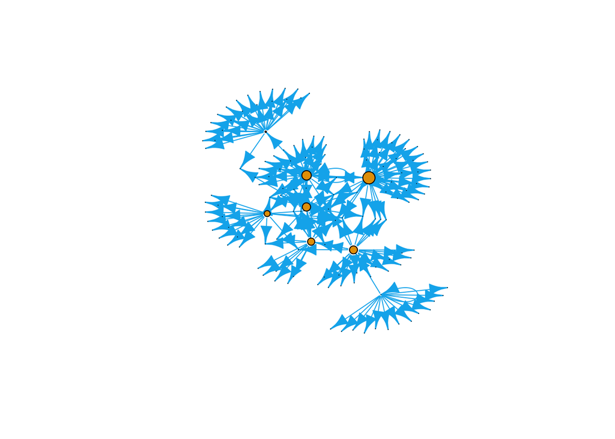

Dans cette exemple, on voit que la majorité des dyades ont le statut nul car de nombreux noeuds ne sont pas connectés et que lorsque arête il y a, elles sont asymétriques :

```r
aidsblog <- simplify(aidsblog)
graph.density(aidsblog)
```

```
## [1] 0.008644308
```

```r
ecount(aidsblog)
```

```
## [1] 183
```

```r
dyad_census(aidsblog)
```

```
## $mut
## [1] 3
##
## $asym
## [1] 177
##
## $null
## [1] 10405
```

- Triades

On peut compter les triangles des manières suivantes.

Nombre de triangles :

```r
length(triangles(karate))
```

```
## [1] 135
```

Nombre de triangles adjacents à chacun des noeuds

```r
count_triangles(karate)
```

```
##  [1] 18 12 11 10  2  3  3  6  5  0  2  0  1  6  1  1  1  1  1  1  1  1  1
## [24]  4  1  1  1  1  1  4  3  3 13 15
```

- Motifs composés de 3 à 4 noeuds (et 1 à 6 arêtes)

Nombre de triades et comptages des différents motifs de taille 3 :

```r
count_motifs(karate, 3)
```

```
## [1] 438
```

```r
motifs(karate, 3)
```

```
## [1]  NA  NA 393  45
```

Nombre de sous-graphes de taille 4 et comptages des différents motifs de taille 4 :

```r
count_motifs(karate, 4)
```

```
## [1] 2363
```

```r
motifs(karate, 4)
```

```
##  [1]   NA   NA   NA   NA 1098   NA  681  452   36   85   11
```

Remarque : le modèle ERGM qui est plus complexe qu’une analyse descriptive est propice au comptage des motifs.

### 3.2.1) Réciprocité et transitivité

- Réciprocité

Rappelons qu’une dyade connectée correspond à une arête qui peut prendre trois états : nul, asymétrique et mutuel. Le cas où une dyade est à l’état mutuel dans un graphe dirigé, c’est à dire que l’arête liant deux noeuds est dirigée vers chacun d’entre eux, est l’exemple même d’une relation dite réciproque.

Soient $\tau_{2-M}(\mathcal{G})$ le nombre de dyades mutuelles et $|\mathcal{E}|$ la taille (nombre d’arêtes) de $\mathcal{G}$.
$$\mathrm{transitivite}(\mathcal{G}) = \frac{\tau_{2-M}(\mathcal{G})}{|\mathcal{E}|}.$$

La réciprocité d’un graphe dirigé se base sur le nombre de dyades mutuelles dans le graphe comparé au nombre total d’arêtes.

```r
reciprocity(aidsblog)
```

```
## [1] 0.03278689
```

Remarque : avec l’option mode=“ratio” dans la fonction reciprocity, on peut calculer le rapport entre dyades mutuelles et asymétriques.

- Transitivité

Rappelons qu’une triade connectée/connexe correspond à un motif à 3 noeuds avec deux arêtes, i.e. un V (étoile à deux branches) et qu’une triade à 3 arêtes est un triangle. Le motif du triangle est l’exemple même d’une relation dite transitive “l’ami.e de mon ami.e est mon ami.e”.

Soient $\tau_{\Delta}(\mathcal{G})$ le nombre de triangles dans $\mathcal{G}$ et $\tau_{3}(\mathcal{G})$ le nombre de triades connectées dans $\mathcal{G}$.
$$\mathrm{transitivite}(\mathcal{G}) = \frac{\tau_{\Delta}(\mathcal{G})}{\tau_3(\mathcal{G})}.$$

La transitivité d’un graphe non dirigé se base sur le nombre de triangles dans le graphe comparé au nombre de V.

```r
transitivity(karate)
```

```
## [1] 0.2556818
```

```r
transitivity(karate, "local", vids=c(1,34))
```

```
## [1] 0.1500000 0.1102941
```

## 3.2) Cliques et densité

- Clique :

Dans un graphe non dirigé, une clique est un sous-graphe dans lequel tous les noeuds sont connectés entre eux. Autrement dit, un ensemble de noeuds pour lequel toute paire de noeuds constitue une arête.

```r
table(sapply(cliques(karate), length))
```

```
##
##  1  2  3  4  5
## 34 78 45 11  2
```

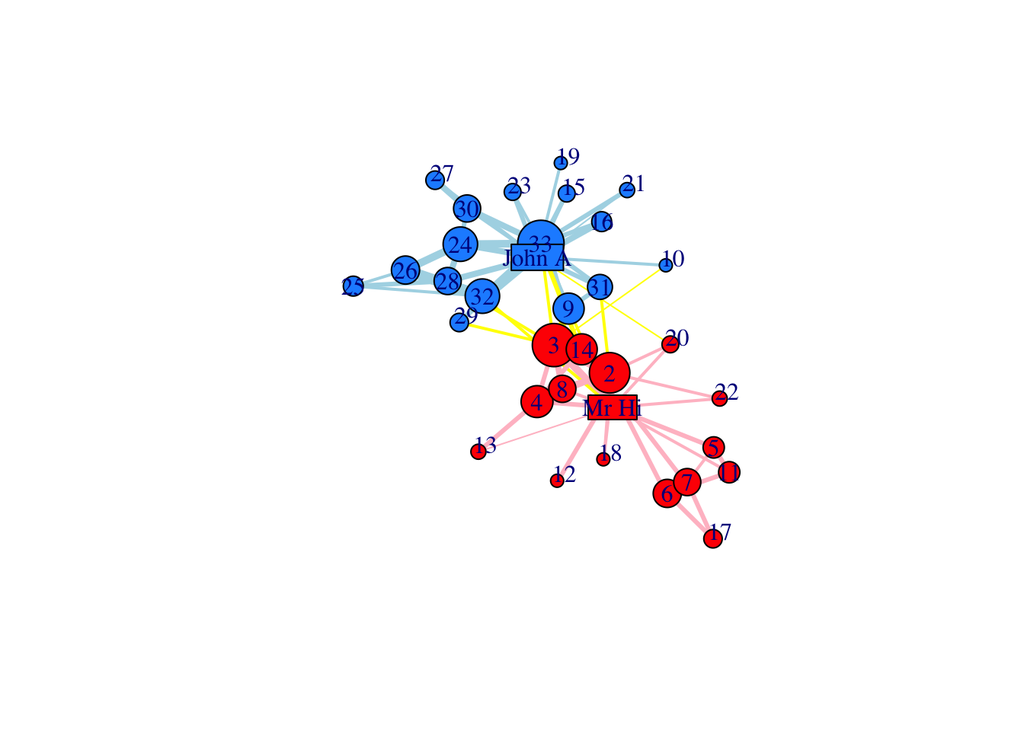

Dans le réseau du club de karaté il y a 34 noeuds (cliques de taille 1), 78 arêtes (cliques de taille 2), 45 triangles (cliques de taille 3), 11 cliques avec 4 noeuds tous connectés et 2 cliques avec 5 noeuds tous connectés.

Pour avoir accès aux individus des cliques avec 5 individus :

```r
cliques(karate, min = 5)
```

```
## [[1]]
## + 5/34 vertices, named, from 4b458a1:
## [1] Mr Hi    Actor 2  Actor 3  Actor 4  Actor 14
##
## [[2]]
## + 5/34 vertices, named, from 4b458a1:
## [1] Mr Hi   Actor 2 Actor 3 Actor 4 Actor 8
```

Graphes induits à partir des relations de l’enseignant et de l’administratif :

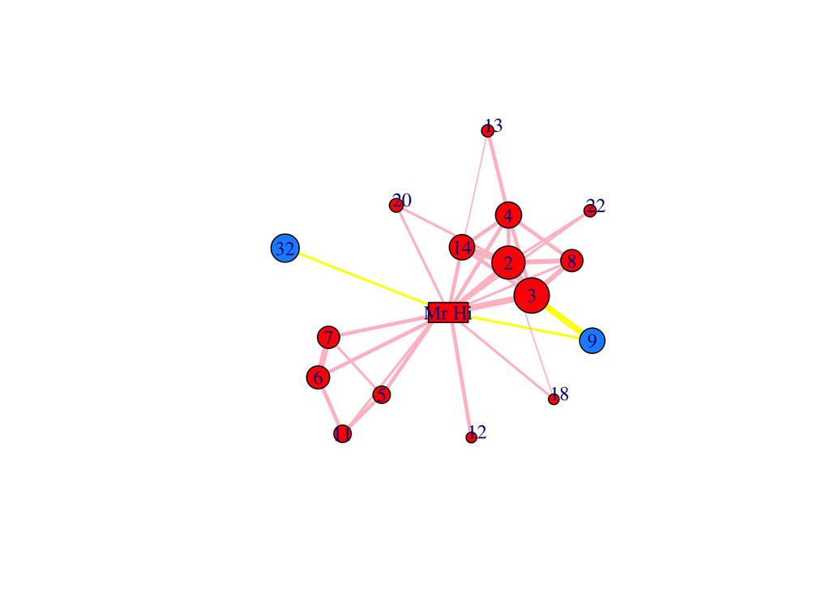

```r
ego.instr <- induced.subgraph(karate, neighborhood(karate, 1, 1)[[1]])
plot(ego.instr)
```

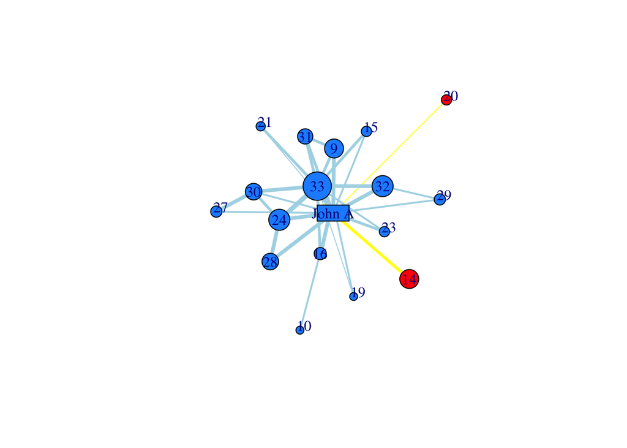

```r
ego.admin <- induced.subgraph(karate, neighborhood(karate, 1, 34)[[1]])
plot(ego.admin)
```

On peut s’intéresser aux cliques qui ne sont pas incluses dans une plus grande, c’est ce qu’on appelle une clique maximale. Par exemple, seules deux cliques de taille 4 sont maximales :

```r
table(sapply(maximal.cliques(karate), length))
```

```
##
##  2  3  4  5
## 11 21  2  2
```

Pour avoir accès à la taille de la plus grande clique :

```r
clique.number(karate)
```

```
## [1] 5
```

```r
clique.number(ego.instr)
```

```
## [1] 5
```

```r
clique.number(ego.admin)
```

```
## [1] 4
```

- Densité :

La densité d’un graphe est définie par
$$\mathrm{densite}(\mathcal{G}) = \frac{2|\mathcal{E}|}{|\mathcal{V}|(|\mathcal{V}| - 1)} = \frac{\bar{D}}{|V|-1},$$
où $\bar{D}$ est le degré moyen. C’est la fréquence d’arêtes potentielles réalisées. Comprise entre 0 et 1, c’est aussi une mesure de proximité à une clique. Une clique a une densité qui vaut 1.

Remarque : pour un graphe dirigé, il n’y a plus le coefficient 2 dans la première expression.

```r
graph.density(karate)
```

```
## [1] 0.1390374
```

```r
graph.density(ego.instr)
```

```
## [1] 0.25
```

```r
graph.density(ego.admin)
```

```
## [1] 0.2091503
```

Les sous-graphes ego-centrés de l’enseignant est de l’administrateur sont plus denses que le graphe du club tout entier, cela se visualise bien sur la représentation graphique.

## 3.3) Partitionnement : modularité

Le partitionnement de graphe en communautés consiste à rechercher des groupes de noeuds relativement bien connectés entre eux et peu d’un groupe à l’autre, autrement dit on constitue des communautés avec un nombre d’arêtes intra-communautaires important et un nombre d’arêtes inter-communautaires faible.

Il existe plusieurs algorithmes qui permettent de faire du partitionnement et en particulier la classification hiérarchique. La modularité est une mesure pour la qualité d’un partitionnement des noeuds d’un graphe en communautés et c’est le critère à optimiser à chaque étape de l’algorithme de classification. Elle est adaptée uniquement aux graphes non dirigés.

- Modularité

La modularité d’une partition $\mathcal{P}$ est définie par :
$$modularite(\mathcal{P})=\frac{1}{2|\mathcal{E}|}\sum_{i,j\in\mathcal{V}}\left(Y_{ij}-\frac{D_iD_j}{2|\mathcal{E}|}\right)\delta_{ij},$$
où $\delta_{ij}$ vaut 1 si $i$ et $j$ sont classés ensemble dans la partition $\mathcal{P}$ et 0 sinon. La modularité décrit donc les écarts entre la proportion d’arêtes dans chacune des classes (liens intra-communauté) et cette même proportion si les arêtes étaient disposées au hasard dans le graphe.

La modularité d’une partition prend ses valeurs entre -1 et 1, plus elle est grande en valeur absolue plus la partition capture des groupes non triviaux.

On présente ici les résultat d’un algorithme hiérarchique de partitionnement qui à chaque étape optimise la modularité définie comme cprécédemment (il existe une définition plus générale) :

```r
kc <- fastgreedy.community(karate)
length(kc)
```

```
## [1] 3
```

```r
sizes(kc)
```

```
## Community sizes
##  1  2  3
## 18 11  5
```

```r
membership(kc)
```

```
##    Mr Hi  Actor 2  Actor 3  Actor 4  Actor 5  Actor 6  Actor 7  Actor 8
##        2        2        2        2        3        3        3        2
##  Actor 9 Actor 10 Actor 11 Actor 12 Actor 13 Actor 14 Actor 15 Actor 16
##        1        1        3        2        2        2        1        1
## Actor 17 Actor 18 Actor 19 Actor 20 Actor 21 Actor 22 Actor 23 Actor 24
##        3        2        1        2        1        2        1        1
## Actor 25 Actor 26 Actor 27 Actor 28 Actor 29 Actor 30 Actor 31 Actor 32
##        1        1        1        1        1        1        1        1
## Actor 33   John A
##        1        1
```

```r
modularity(kc)
```

```
## [1] 0.4345215
```

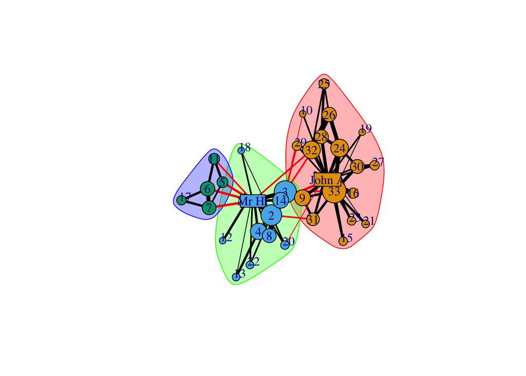

```r
plot(kc,karate)
```